# pandas

```python
import pandas as pd
import seaborn as sns
import matplotlib.pyplot as plt
%matplotlib inline
sns.set()
```

```python
oo = pd.read_csv('/home/scott/Desktop/Johnny Python/data/olympics.csv', skiprows=4)
oo.head()
```

|  | City | Edition | Sport | Discipline | Athlete | NOC | Gender | Event | Event_gender | Medal |
| --- | --- | --- | --- | --- | --- | --- | --- | --- | --- | --- |
| 0 | Athens | 1896 | Aquatics | Swimming | HAJOS, Alfred | HUN | Men | 100m freestyle | M | Gold |
| 1 | Athens | 1896 | Aquatics | Swimming | HERSCHMANN, Otto | AUT | Men | 100m freestyle | M | Silver |
| 2 | Athens | 1896 | Aquatics | Swimming | DRIVAS, Dimitrios | GRE | Men | 100m freestyle for sailors | M | Bronze |
| 3 | Athens | 1896 | Aquatics | Swimming | MALOKINIS, Ioannis | GRE | Men | 100m freestyle for sailors | M | Gold |
| 4 | Athens | 1896 | Aquatics | Swimming | CHASAPIS, Spiridon | GRE | Men | 100m freestyle for sailors | M | Silver |

## Basic Analyses

```python
oo.shape
```

```
(29216, 10)
```

```python
oo.info()
```

```
<class 'pandas.core.frame.DataFrame'>
RangeIndex: 29216 entries, 0 to 29215
Data columns (total 10 columns):
City            29216 non-null object
Edition         29216 non-null int64
Sport           29216 non-null object
Discipline      29216 non-null object
Athlete         29216 non-null object
NOC             29216 non-null object
Gender          29216 non-null object
Event           29216 non-null object
Event_gender    29216 non-null object
Medal           29216 non-null object
dtypes: int64(1), object(9)
memory usage: 2.2+ MB
```

```python
oo.Gender.value_counts()
```

```
Men      21721
Women     7495
Name: Gender, dtype: int64
```

```python
ath = oo.Athlete.sort_values()
```

```python
oo.sort_values(by=['Edition', "Athlete"])
```

|  | City | Edition | Sport | Discipline | Athlete | NOC | Gender | Event | Event_gender | Medal |
| --- | --- | --- | --- | --- | --- | --- | --- | --- | --- | --- |
| 7 | Athens | 1896 | Aquatics | Swimming | ANDREOU, Joannis | GRE | Men | 1200m freestyle | M | Silver |
| 82 | Athens | 1896 | Gymnastics | Artistic G. | ANDRIAKOPOULOS, Nicolaos | GRE | Men | rope climbing | M | Gold |
| 110 | Athens | 1896 | Gymnastics | Artistic G. | ANDRIAKOPOULOS, Nicolaos | GRE | Men | team, parallel bars | M | Silver |
| 111 | Athens | 1896 | Gymnastics | Artistic G. | ATHANASOPOULOS, Spyros | GRE | Men | team, parallel bars | M | Silver |
| 48 | Athens | 1896 | Cycling | Cycling Road | BATTEL, Edward | GBR | Men | individual road race | M | Bronze |
| ... | ... | ... | ... | ... | ... | ... | ... | ... | ... | ... |
| 28095 | Beijing | 2008 | Equestrian | Dressage | ZU-SAYN WITTGENSTEIN, Nathalie | DEN | Women | team | X | Bronze |
| 28819 | Beijing | 2008 | Sailing | Sailing | ZUBARI, Shahar | ISR | Men | RS:X - Windsurfer | M | Bronze |
| 28977 | Beijing | 2008 | Taekwondo | Taekwondo | ZUBCIC, Martina | CRO | Women | 49 - 57 kg | W | Bronze |
| 28387 | Beijing | 2008 | Gymnastics | Rhythmic G. | ZUEVA, Natalia | RUS | Women | group competition | W | Gold |
| 29007 | Beijing | 2008 | Tennis | Tennis | ZVONAREVA, Vera | RUS | Women | singles | W | Bronze |

29216 rows × 10 columns

## Boolean Indexing

```python
oo[(oo.Medal=='Gold') & (oo.Gender=='Women')]
```

|  | City | Edition | Sport | Discipline | Athlete | NOC | Gender | Event | Event_gender | Medal |
| --- | --- | --- | --- | --- | --- | --- | --- | --- | --- | --- |
| 417 | Paris | 1900 | Golf | Golf | ABBOTT, Margaret Ives | USA | Women | individual | W | Gold |
| 641 | Paris | 1900 | Tennis | Tennis | COOPER, Charlotte | GBR | Women | mixed doubles | X | Gold |
| 649 | Paris | 1900 | Tennis | Tennis | COOPER, Charlotte | GBR | Women | singles | W | Gold |
| 710 | St Louis | 1904 | Archery | Archery | HOWELL, Matilda Scott | USA | Women | double columbia round (50y - 40y - 30y) | W | Gold |
| 713 | St Louis | 1904 | Archery | Archery | HOWELL, Matilda Scott | USA | Women | double national round (60y - 50y) | W | Gold |
| ... | ... | ... | ... | ... | ... | ... | ... | ... | ... | ... |
| 29134 | Beijing | 2008 | Weightlifting | Weightlifting | CAO, Lei | CHN | Women | 75kg | W | Gold |
| 29147 | Beijing | 2008 | Wrestling | Wrestling Free. | HUYNH, Carol | CAN | Women | - 48kg | W | Gold |
| 29155 | Beijing | 2008 | Wrestling | Wrestling Free. | YOSHIDA, Saori | JPN | Women | 48 - 55kg | W | Gold |
| 29163 | Beijing | 2008 | Wrestling | Wrestling Free. | ICHO, Kaori | JPN | Women | 55 - 63kg | W | Gold |
| 29171 | Beijing | 2008 | Wrestling | Wrestling Free. | WANG, Jiao | CHN | Women | 63 - 72kg | W | Gold |

2485 rows × 10 columns

## String Handling

```python
oo[oo.Athlete.str.contains('Florence')]
```

|  | City | Edition | Sport | Discipline | Athlete | NOC | Gender | Event | Event_gender | Medal |
| --- | --- | --- | --- | --- | --- | --- | --- | --- | --- | --- |
| 1843 | London | 1908 | Skating | Figure skating | SYERS, Florence | GBR | Women | individual | W | Gold |
| 1848 | London | 1908 | Skating | Figure skating | SYERS, Florence | GBR | Women | pairs | X | Bronze |
| 4173 | Paris | 1924 | Aquatics | Swimming | BARKER, Florence | GBR | Women | 4x100m freestyle relay | W | Silver |
| 8162 | Helsinki | 1952 | Athletics | Athletics | FOULDS-PAUL, June Florence | GBR | Women | 4x100m relay | W | Bronze |
| 9060 | Melbourne / Stockholm | 1956 | Athletics | Athletics | FOULDS-PAUL, June Florence | GBR | Women | 4x100m relay | W | Silver |
| 10849 | Tokyo | 1964 | Athletics | Athletics | AMOORE-POLLOCK, Judith Florence | AUS | Women | 400m | W | Bronze |
| 16817 | Los Angeles | 1984 | Athletics | Athletics | GRIFFITH-JOYNER, Florence | USA | Women | 200m | W | Silver |
| 18287 | Seoul | 1988 | Athletics | Athletics | GRIFFITH-JOYNER, Florence | USA | Women | 100m | W | Gold |
| 18305 | Seoul | 1988 | Athletics | Athletics | GRIFFITH-JOYNER, Florence | USA | Women | 200m | W | Gold |
| 18347 | Seoul | 1988 | Athletics | Athletics | GRIFFITH-JOYNER, Florence | USA | Women | 4x100m relay | W | Gold |
| 18374 | Seoul | 1988 | Athletics | Athletics | GRIFFITH-JOYNER, Florence | USA | Women | 4x400m relay | W | Silver |

## Questions

#### In which events did Jesse Owens medal?

```python
jo = oo[oo.Athlete=='OWENS, Jesse']
jo.Event.value_counts()
```

```
100m            1
4x100m relay    1
long jump       1
200m            1
Name: Event, dtype: int64
```

#### Which country has won the most men's gold medals in singles badminton?

```python
# To figure out if 'Badminton' is a Sport or an Event
oo.Sport.value_counts()
```

```
Aquatics             3828
Athletics            3448
Rowing               2523
Gymnastics           2214
Fencing              1547
Football             1387
Hockey               1325
Wrestling            1140
Shooting             1105
Sailing              1061
Cycling              1025
Canoe / Kayak        1002
Basketball            940
Volleyball            910
Equestrian            894
Handball              886
Boxing                842
Weightlifting         548
Judo                  435
Baseball              335
Archery               305
Tennis                272
Rugby                 192
Softball              180
Modern Pentathlon     174
Badminton             120
Table Tennis          120
Tug of War             94
Taekwondo              80
Polo                   66
Lacrosse               59
Golf                   30
Ice Hockey             27
Skating                27
Cricket                24
Triathlon              18
Rackets                10
Croquet                 8
Water Motorsports       5
Basque Pelota           4
Roque                   3
Jeu de paume            3
Name: Sport, dtype: int64
```

```python
gbm = oo[(oo.Medal == 'Gold') & (oo.Gender == 'Men') & (oo.Sport == "Badminton")]
gbm.sort_values(by='Athlete').head()
```

|  | City | Edition | Sport | Discipline | Athlete | NOC | Gender | Event | Event_gender | Medal |
| --- | --- | --- | --- | --- | --- | --- | --- | --- | --- | --- |
| 20045 | Barcelona | 1992 | Badminton | Badminton | BUDI KUSUMA, Alan | INA | Men | singles | M | Gold |
| 23701 | Sydney | 2000 | Badminton | Badminton | GUNAWAN, Tony | INA | Men | doubles | M | Gold |
| 25718 | Athens | 2004 | Badminton | Badminton | HA, Tae-Kwon | KOR | Men | doubles | M | Gold |
| 25734 | Athens | 2004 | Badminton | Badminton | HIDAYAT, Taufik | INA | Men | singles | M | Gold |
| 21787 | Atlanta | 1996 | Badminton | Badminton | HOYER-LARSEN, Poul Erik | DEN | Men | singles | M | Gold |

#### Which 3 countries have won the most medals in recent years (84-08)?

```python
rec = oo[oo.Edition >= 1984]
rec.NOC.value_counts().head(3)
```

```
USA    1837
AUS     762
GER     691
Name: NOC, dtype: int64
```

#### Male Gold medal winners from 100m T&F sprint event, sort by most recent. City, edition, athlete, country.

```python
# To see how sprint events are named
oo.Event.value_counts()
```

```
football                          1387
hockey                            1325
team competition                  1018
basketball                         940
eight with coxswain (8+)           918
                                  ...
moving bird target, 50m              2
65.77 - 71.67kg (middleweight)       2
class B up to 60 feet                2
47.63 - 52.16kg (bantamweight)       2
open class A                         1
Name: Event, Length: 577, dtype: int64
```

```python
gmh = oo[(oo.Gender == 'Men') & (oo.Medal == 'Gold') & (oo.Event == '100m')]
gmh.sort_values(by="Edition", ascending=False)[['City',"Edition",'Athlete','NOC']].head()
```

|  | City | Edition | Athlete | NOC |
| --- | --- | --- | --- | --- |
| 27552 | Beijing | 2008 | BOLT, Usain | JAM |
| 25539 | Athens | 2004 | GATLIN, Justin | USA |
| 23521 | Sydney | 2000 | GREENE, Maurice | USA |
| 21598 | Atlanta | 1996 | BAILEY, Donovan | CAN |
| 19859 | Barcelona | 1992 | CHRISTIE, Linford | GBR |

## Plotting

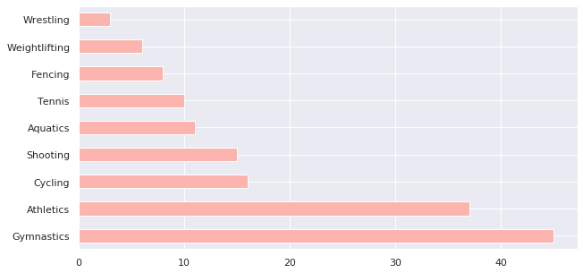

```python
fo = oo[oo.Edition == 1896]
fo.Sport.value_counts().plot(kind='barh', figsize=(10,5), colormap='Pastel1');
```

```python
sns.countplot(x = 'Medal', data = oo, hue = 'Gender');
```

[output not shown]

#### Plot number of medals by Chinese team (both) in 2008

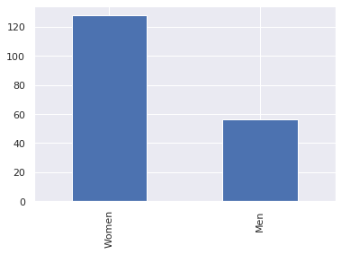

```python
chi = oo[(oo.NOC == 'CHN') & (oo.Edition == 2008)]
chi.Gender.value_counts().plot(kind='bar');
```

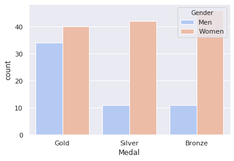

```python
sns.countplot(x = 'Medal', data = chi, hue = 'Gender', palette = 'coolwarm', order = ['Gold', 'Silver', 'Bronze']);
```

## Indexing

```python
# Reset index
oo.reset_index(inplace=True)
```

```python
# Set index
ath = oo.set_index('Athlete')
```

```python
ath.sort_index(inplace=True)
```

```python
ath.loc['BOLT, Usain']
```

| Athlete | City | Edition | Sport | Discipline | NOC | Gender | Event | Event_gender | Medal |
| --- | --- | --- | --- | --- | --- | --- | --- | --- | --- |
| BOLT, Usain | Beijing | 2008 | Athletics | Athletics | JAM | Men | 200m | M | Gold |
| BOLT, Usain | Beijing | 2008 | Athletics | Athletics | JAM | Men | 4x100m relay | M | Gold |
| BOLT, Usain | Beijing | 2008 | Athletics | Athletics | JAM | Men | 100m | M | Gold |

```python
oo.iloc[[1700, 90]]
```

|  | Athlete | City | Edition | Sport | Discipline | NOC | Gender | Event | Event_gender | Medal |
| --- | --- | --- | --- | --- | --- | --- | --- | --- | --- | --- |
| 1700 | RABOT, Pierre | London | 1908 | Sailing | Sailing | FRA | Men | 6m | X | Bronze |
| 90 | NEUKIRCH, Karl | Athens | 1896 | Gymnastics | Artistic G. | GER | Men | team, horizontal bar | M | Gold |

```python
oo.iloc[1:4]
```

|  | Athlete | City | Edition | Sport | Discipline | NOC | Gender | Event | Event_gender | Medal |
| --- | --- | --- | --- | --- | --- | --- | --- | --- | --- | --- |
| 1 | HERSCHMANN, Otto | Athens | 1896 | Aquatics | Swimming | AUT | Men | 100m freestyle | M | Silver |
| 2 | DRIVAS, Dimitrios | Athens | 1896 | Aquatics | Swimming | GRE | Men | 100m freestyle for sailors | M | Bronze |
| 3 | MALOKINIS, Ioannis | Athens | 1896 | Aquatics | Swimming | GRE | Men | 100m freestyle for sailors | M | Gold |

#### Plot the total number of medals awarded at each of the Olympic games

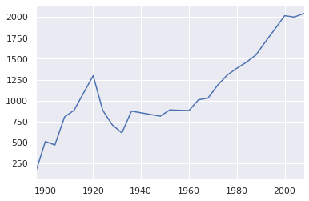

```python
oo.Edition.value_counts().sort_index().plot()
```

#### Which countries did not win a medal in 2008 / how many were there?

```python
lo = oo[oo.Edition == 2008]
```

```python
noc = pd.read_csv('/home/scott/Desktop/data/Summer Olympic medallists 1896 to 2008 - IOC COUNTRY CODES.csv')
```

```python
# Check to see if any differences exist between 'Country' and 'Country.1'
noc[noc['Country'] != noc['Country.1']]
```

|  | Country | Int Olympic Committee code | ISO code | Country.1 |
| --- | --- | --- | --- | --- |

```python
noc.set_index('Int Olympic Committee code', inplace=True)
```

```python
medal_2008 = lo.NOC.value_counts()
```

```python
noc['medal_2008'] = medal_2008
```

```python
noc[noc.medal_2008.isnull()]
```

| Int Olympic Committee code | Country | ISO code | Country.1 | medal_2008 |
| --- | --- | --- | --- | --- |
| ALB | Albania | AL | Albania | NaN |
| ASA | American Samoa* | AS | American Samoa* | NaN |
| AND | Andorra | AD | Andorra | NaN |
| ANG | Angola | AO | Angola | NaN |
| ANT | Antigua and Barbuda | AG | Antigua and Barbuda | NaN |
| ... | ... | ... | ... | ... |
| URU | Uruguay | UY | Uruguay | NaN |
| VAN | Vanuatu | VU | Vanuatu | NaN |
| ISV | Virgin Islands* | VI | Virgin Islands* | NaN |
| YEM | Yemen | YE | Yemen | NaN |
| ZAM | Zambia | ZM | Zambia | NaN |

117 rows × 4 columns

## Groupby

```python
oo.groupby('Edition')
```

```
<pandas.core.groupby.generic.DataFrameGroupBy object at 0x7fbf747c6090>
```

```python
for group_key,group_value in oo.groupby('Edition'):
    print(group_key)
    print(group_value)
```

[output not shown]

```python
oo.groupby(['Edition', 'NOC', 'Medal']).agg({'Edition' :['min','max','count']})
```

| Edition | NOC | Medal | Edition min | Edition max | Edition count |
| --- | --- | --- | --- | --- | --- |
| 1896 | AUS | Gold | 1896 | 1896 | 2 |
|  | AUT | Bronze | 1896 | 1896 | 2 |
|  |  | Gold | 1896 | 1896 | 2 |
|  |  | Silver | 1896 | 1896 | 1 |
|  | DEN | Bronze | 1896 | 1896 | 3 |
| ... | ... | ... | ... | ... | ... |
| 2008 | UZB | Silver | 2008 | 2008 | 2 |
|  | VEN | Bronze | 2008 | 2008 | 1 |
|  | VIE | Silver | 2008 | 2008 | 1 |
|  | ZIM | Gold | 2008 | 2008 | 1 |
|  |  | Silver | 2008 | 2008 | 3 |

2356 rows × 3 columns

```python
oo.loc[oo.Athlete == "LEWIS, Carl"].groupby('Athlete').agg({'Edition':['min', 'max', 'count']})
```

| Athlete | Edition min | Edition max | Edition count |
| --- | --- | --- | --- |
| LEWIS, Carl | 1984 | 1996 | 10 |

#### Using Groupby, plot the total number of medals awarded at each of the Olympic games

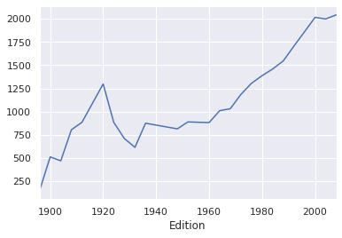

```python
oo.groupby('Edition').size().plot()
```

#### List of total medals won for each country ever, for each country include year of first and most recent medal wins

```python
oo.groupby('NOC').agg({'Edition' :['count','min','max']})
```

| NOC | Edition count | Edition min | Edition max |
| --- | --- | --- | --- |
| AFG | 1 | 2008 | 2008 |
| AHO | 1 | 1988 | 1988 |
| ALG | 14 | 1984 | 2008 |
| ANZ | 29 | 1908 | 1912 |
| ARG | 239 | 1924 | 2008 |
| ... | ... | ... | ... |
| VIE | 2 | 2000 | 2008 |
| YUG | 435 | 1924 | 2000 |
| ZAM | 2 | 1984 | 1996 |
| ZIM | 23 | 1980 | 2008 |
| ZZX | 48 | 1896 | 1904 |

138 rows × 3 columns

## Reshape

```python
mw = oo[(oo.Edition == 2008) & ((oo.Event == '100m') | (oo.Event == '200m'))]
mw.head()
```

|  | Athlete | City | Edition | Sport | Discipline | NOC | Gender | Event | Event_gender | Medal |
| --- | --- | --- | --- | --- | --- | --- | --- | --- | --- | --- |
| 27551 | DIX, Walter | Beijing | 2008 | Athletics | Athletics | USA | Men | 100m | M | Bronze |
| 27552 | BOLT, Usain | Beijing | 2008 | Athletics | Athletics | JAM | Men | 100m | M | Gold |
| 27553 | THOMPSON, Richard | Beijing | 2008 | Athletics | Athletics | TRI | Men | 100m | M | Silver |
| 27554 | FRASER, Shelly-ann | Beijing | 2008 | Athletics | Athletics | JAM | Women | 100m | W | Gold |
| 27555 | SIMPSON, Sherone | Beijing | 2008 | Athletics | Athletics | JAM | Women | 100m | W | Silver |

```python
g = mw.groupby(['NOC', 'Gender', 'Discipline', 'Event']).size()
```

```python
df = g.unstack(['Discipline', 'Event'])
df
```

| NOC | Discipline Event Gender | Athletics 100m | Athletics 200m |
| --- | --- | --- | --- |
| JAM | Men | 1.0 | 1.0 |
|  | Women | 3.0 | 2.0 |
| TRI | Men | 1.0 | NaN |
| USA | Men | 1.0 | 2.0 |
|  | Women | NaN | 1.0 |

```python
df.stack()
```

| NOC | Gender | Discipline Event | Athletics |
| --- | --- | --- | --- |
| JAM | Men | 100m | 1.0 |
|  |  | 200m | 1.0 |
|  | Women | 100m | 3.0 |
|  |  | 200m | 2.0 |
| TRI | Men | 100m | 1.0 |
| USA | Men | 100m | 1.0 |
|  |  | 200m | 2.0 |
|  | Women | 200m | 1.0 |

```python
df.unstack()
```

| Discipline Event Gender NOC | Athletics 100m Men | Athletics 100m Women | Athletics 200m Men | Athletics 200m Women |
| --- | --- | --- | --- | --- |
| JAM | 1.0 | 3.0 | 1.0 | 2.0 |
| TRI | 1.0 | NaN | NaN | NaN |
| USA | 1.0 | NaN | 2.0 | 1.0 |

#### Plot the number of gold medals won by US male and female athletes throughout Olympic history

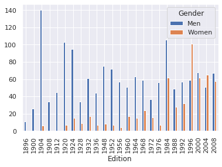

```python
gm = oo[(oo.Medal=='Gold') & (oo.NOC == 'USA')]
gm.groupby(['Edition', 'Gender']).size().unstack('Gender', fill_value=0).plot(kind='bar')
```

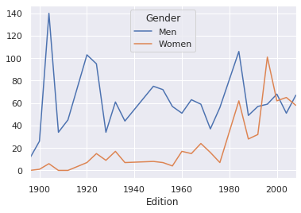

```python
gm.groupby(['Edition', 'Gender']).size().unstack('Gender', fill_value=0).plot()
```

#### Plot 5 athletes with most gold medals in Olympic history, considering silver and bronze for ties

```python
g = oo.groupby(['Athlete', 'Medal']).size().unstack('Medal', fill_value=0)
```

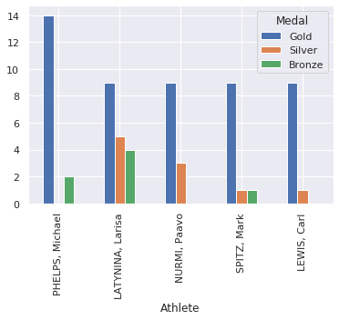

```python
g.sort_values(['Gold', 'Silver', 'Bronze'], ascending=False)[['Gold', 'Silver', 'Bronze']].head(5).plot(kind='bar')
```

#### Pivot Table

```python
oo.pivot_table('NOC', index='Gender', columns='Medal')
```